# Pre-processing of hyperspectral data 2021

Florian Tanner

2022-07-04 15:42:33

Multiple hyperspectral image data pre-processing methods are implemented and pre-processed data is exported for predictive modeling.

## Load packages

```r
rm(list=ls())
library(tidyverse)
```

```r
library(ggplot2); theme_set(theme_bw())
library(prospectr)
library(patchwork)
```

## Possible reprocessing steps

- Using only VNIR data vs using full spectrum data
- Smoothing
- Normalising SWIR reflectance to VNIR reflectance
  - Correcting baseline of SWIR data as both sensors measure different reflectance
- Binning

### Load data

```r
hyperspec_2021 <- read_csv("../../raw_data/hyperspectral/reflectance_2021.csv")
sample_date <- "2021-06-03"
sample_id <- "085462-C"
```

### Create matrix of possible preprocessing steps

- Adding the various dates to it

```r
pre_processing_steps <- expand.grid(date = c(unique(hyperspec_2021$date)),
                                    cameras = c("VNIR", "VNIR-SWIR"),
                                    smoothing = c("Unsmoothed", "Sav-Gol"),
                                    binning = c("None", "FWHM", "Double FWHM"))
```

## Smoothing

### Prepare data for smoothing

- prospectr functions take a wide matrix, original data is in long format. SWIR and VNIR are split to accomodate for different smoothing parameters
- One pot was imaged multiple times, therefore the reflectance is being averaged with values_fn = mean

```r
idcols <- c("id_tag", "date")
hyperspec_2021$wavelength_chr <- as.character(hyperspec_2021$wavelength) # making a character version of this column to facilitate joins

VNIR_wide <- hyperspec_2021 |>
  filter(camera == "VNIR") |>
  pivot_wider(id_cols = idcols, names_from = wavelength_chr, values_from = reflectance,values_fn = mean)
```

```
## Note: Using an external vector in selections is ambiguous.
## ℹ Use `all_of(idcols)` instead of `idcols` to silence this message.
## ℹ See <https://tidyselect.r-lib.org/reference/faq-external-vector.html>.
```

```r
VNIR_ref_matrix <- VNIR_wide |> select(-idcols)
VNIR_id_matrix <- VNIR_wide |> select(idcols)

SWIR_wide <- hyperspec_2021 |>
  filter(camera == "SWIR") |>
  pivot_wider(id_cols = idcols, names_from = wavelength_chr, values_from = reflectance,values_fn = mean)
SWIR_ref_matrix <- SWIR_wide |> select(-idcols)
SWIR_id_matrix <- SWIR_wide |> select(idcols)
```

### Choosing smoothing parameters visually

- Window lengths for smoothing are flexible and are chosen here upon visual inspection of smoothed and unsmoothed reflectance
- Creating a function to plot different smoothing parameters

```r
test_savgol_param <- function(ref_matrix,
                              id_matrix,
                              poly_order = 3,
                              window_length = c(3,5,7,9,11,13,15,17,19),
                              start_wavelength = 400,
                              stop_wavelength = 1000,
                              original_dat = VNIR_ref,
                              select_id =  sample_id,
                              select_date = sample_date){
  for(wl in window_length){
    print(paste0("Window length = ", wl, " , Polynomial order = ", poly_order))
    smoothed_df <- cbind(as.data.frame(savitzkyGolay(ref_matrix, p = poly_order, w = wl, m = 0)), id_matrix) |>
      pivot_longer(cols = -idcols, names_to = "wavelength_chr",  values_to = "reflectance_smoothed")
    smoothed_df$wavelength_chr <- as.numeric(smoothed_df$wavelength_chr)
    s <- smoothed_df |> filter(id_tag == select_id,
                                date == as.Date(select_date),
                                wavelength_chr > start_wavelength, wavelength_chr<stop_wavelength)
    original_dat$wavelength_chr <- as.numeric(original_dat$wavelength_chr)
    o <- original_dat |> filter(id_tag == select_id,
                                 date == as.Date(select_date),
                                 wavelength_chr > start_wavelength, wavelength_chr<stop_wavelength)
    p_smooth <- ggplot(s) +
      geom_line(aes(x = wavelength_chr, y = reflectance_smoothed, group = id_tag), color= "red") +
      geom_line(data = o, aes(x = wavelength_chr, y = reflectance, group = id_tag), color= "black", alpha = 0.5) +
      labs(title = paste0("P. order = ", poly_order, " Window = ", wl), x = "Wavelength", y = "Reflectance")
    plot(p_smooth)
    if(length(window_length) == 1){
      return(p_smooth)}
    else{
    }
  }
}
```

### Testing smoothing params from 450-550 nm

- Further wavelength areas can be tested, but only one region for each camera is shown here to keep the code somewhat short.

```
## [1] "Window length = 5 , Polynomial order = 3"
```

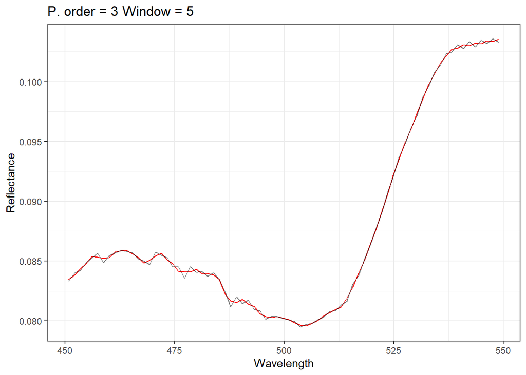

```
## [1] "Window length = 7 , Polynomial order = 3"
```

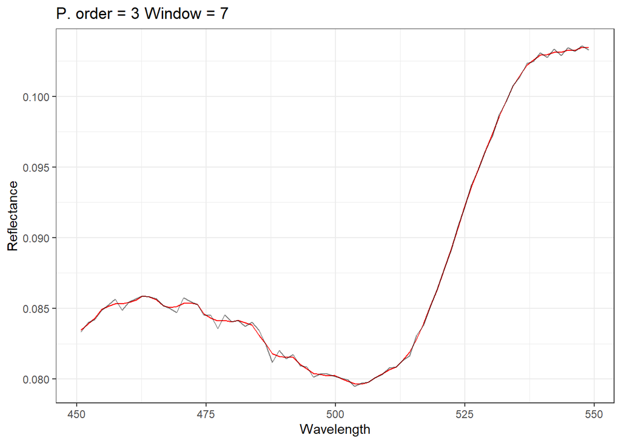

```
## [1] "Window length = 9 , Polynomial order = 3"
```

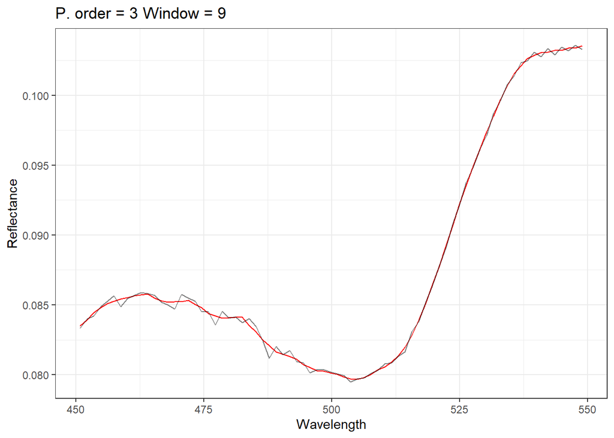

```
## [1] "Window length = 13 , Polynomial order = 3"
```

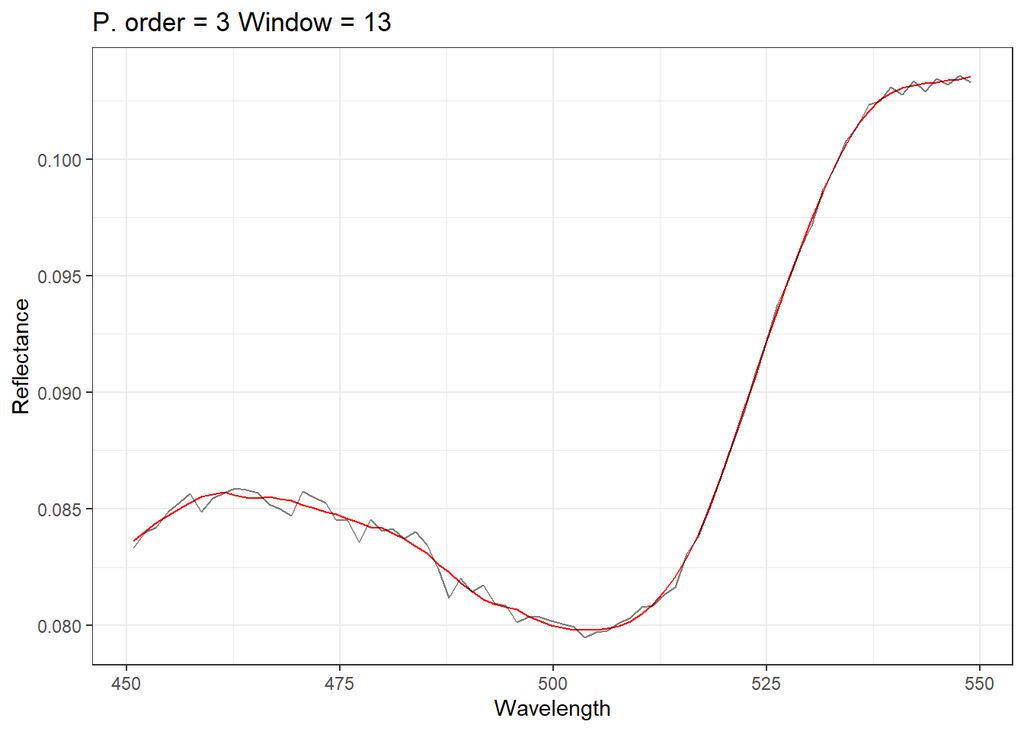

```
## [1] "Window length = 15 , Polynomial order = 3"
```

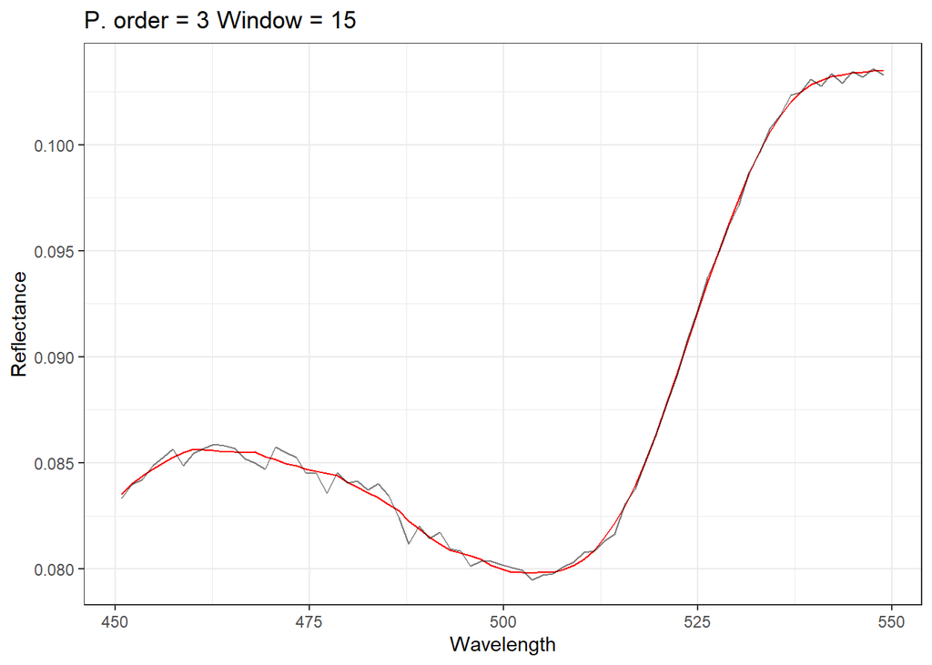

```
## [1] "Window length = 17 , Polynomial order = 3"
```

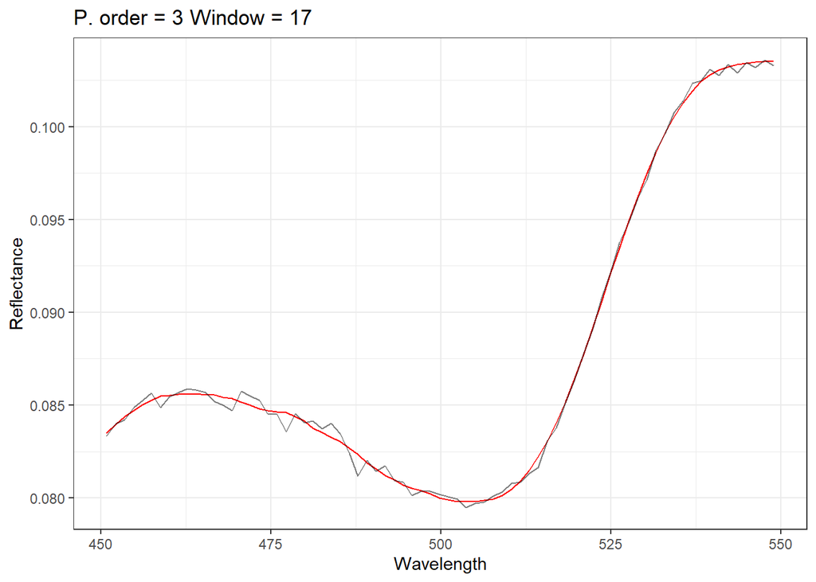

```
## [1] "Window length = 19 , Polynomial order = 3"
```

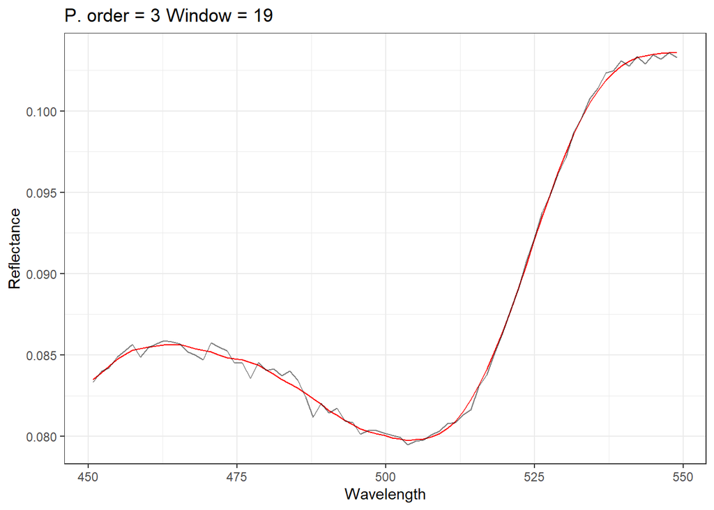

```
## [1] "Window length = 21 , Polynomial order = 3"
```

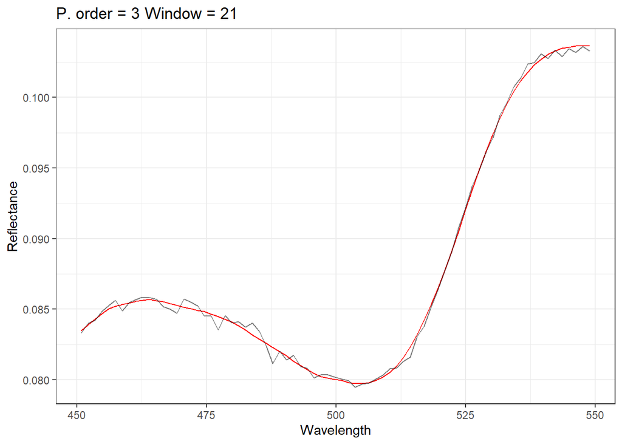

```r
test_savgol_param(ref_matrix = VNIR_ref_matrix,
                  id_matrix = VNIR_id_matrix,
                  window_length = c(5,7,9,13, 15, 17, 19, 21),
                  start_wavelength = 450,
                  stop_wavelength = 550,
                  original_dat = hyperspec_2021 |> filter(camera == "VNIR"))
```

### Testing smoothing params from 900-2600 nm

```
## [1] "Window length = 5 , Polynomial order = 3"
```

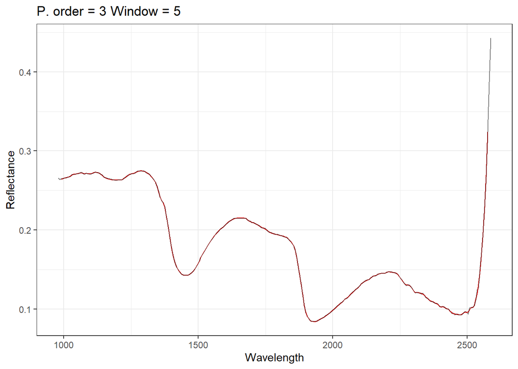

```
## [1] "Window length = 7 , Polynomial order = 3"
```

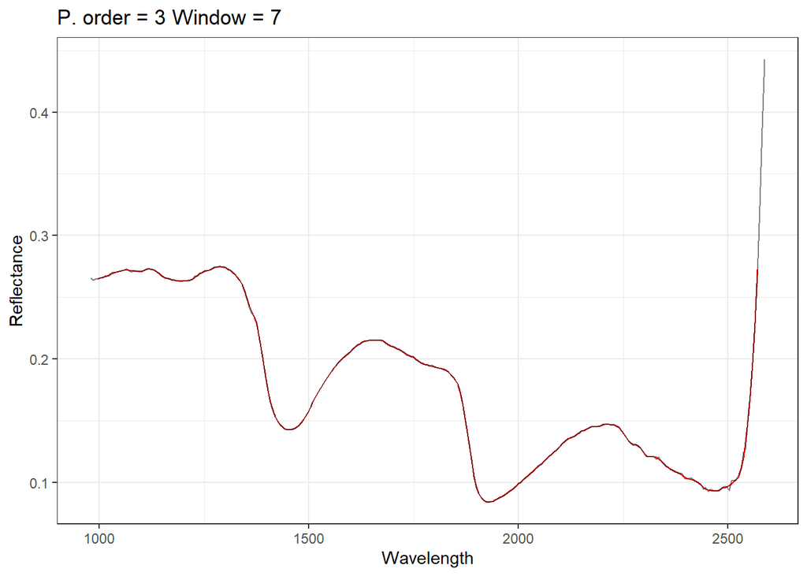

```
## [1] "Window length = 9 , Polynomial order = 3"
```

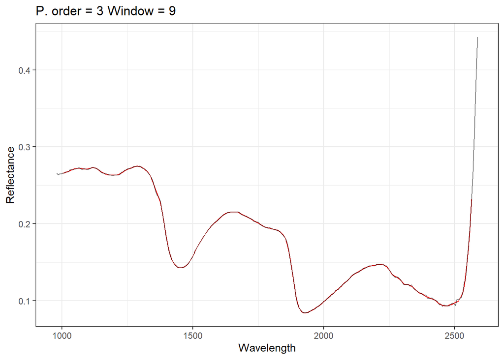

```
## [1] "Window length = 11 , Polynomial order = 3"
```

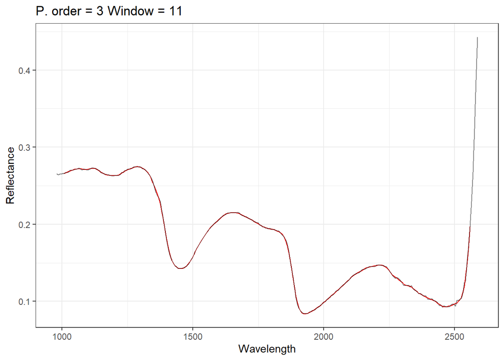

```
## [1] "Window length = 13 , Polynomial order = 3"
```

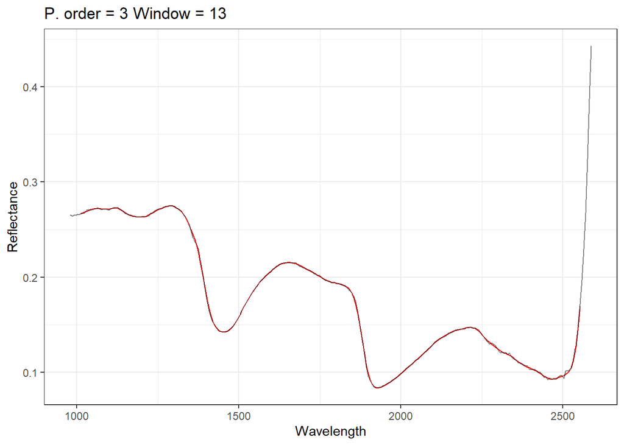

```
## [1] "Window length = 15 , Polynomial order = 3"
```

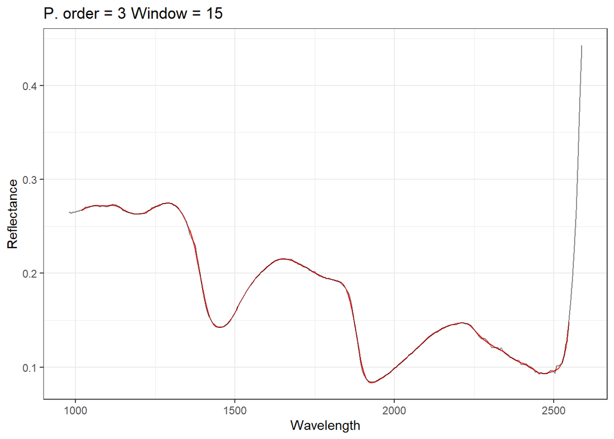

```r
test_savgol_param(ref_matrix = SWIR_ref_matrix,
                  id_matrix = SWIR_id_matrix,
                  window_length = c(5,7,9,11,13,15),
                  start_wavelength = 900,
                  stop_wavelength = 2600,
                  original_dat = hyperspec_2021 |> filter(camera == "SWIR"))
```

### Smoothing VNIR data

```r
VNIR_wl = 19
VNIR_poly = 3
VNIR_smoothed <- cbind(as.data.frame(savitzkyGolay(VNIR_ref_matrix,p = VNIR_poly, w = VNIR_wl , m = 0)), VNIR_id_matrix) |>
  pivot_longer(cols = -idcols, names_to = "wavelength_chr",  values_to = "Smoothed_reflectance_chosen_wl")

VNIR_smoothed_out <- hyperspec_2021 |>
  filter(camera == "VNIR") |>
  left_join(VNIR_smoothed)
```

- Savitzky-Golay smoothing truncates the ends of the spectrum, therefore, the curve is padded with a smaller window length

```r
VNIR_smoothed_ends <- cbind(as.data.frame(savitzkyGolay(VNIR_ref_matrix,p = 3, w = 5 , m = 0)), VNIR_id_matrix) |>
  pivot_longer(cols = -idcols, names_to = "wavelength_chr",  values_to = "Smoothed_reflectance_w5")



VNIR_smoothed_padded_out <- VNIR_smoothed_out |>
  left_join(VNIR_smoothed_ends) |>
  mutate(Smoothed_reflectance = coalesce(Smoothed_reflectance_chosen_wl, Smoothed_reflectance_w5))
```

### Smoothing SWIR data

```r
SWIR_wl = 9
SWIR_poly = 3
SWIR_smoothed <- cbind(as.data.frame(savitzkyGolay(SWIR_ref_matrix,p = SWIR_poly, w = SWIR_wl , m = 0)), SWIR_id_matrix) |>
  pivot_longer(cols = -idcols, names_to = "wavelength_chr",  values_to = "Smoothed_reflectance_chosen_wl")

SWIR_smoothed_out <- hyperspec_2021 |>
  filter(camera == "SWIR") |>
  left_join(SWIR_smoothed)
```

- Savitzky-Golay smoothing truncates the ends of the spectrum, therefore, the curve is padded with a smaller window length

```r
SWIR_smoothed_ends <- cbind(as.data.frame(savitzkyGolay(SWIR_ref_matrix,p = 3, w = 5 , m = 0)), SWIR_id_matrix) |>
  pivot_longer(cols = -idcols, names_to = "wavelength_chr",  values_to = "Smoothed_reflectance_w5")



SWIR_smoothed_padded_out <- SWIR_smoothed_out |>
  left_join(SWIR_smoothed_ends) |>
  mutate(Smoothed_reflectance = coalesce(Smoothed_reflectance_chosen_wl, Smoothed_reflectance_w5))
```

### Joining smoothed VNIR and SWIR data again

```r
smoothed_hyperspec_2021 <- VNIR_smoothed_padded_out |>
  rename(reflectance_raw = reflectance, reflectance_smoothed = Smoothed_reflectance) |>
  select(-Smoothed_reflectance_chosen_wl, -Smoothed_reflectance_w5, -wavelength_chr) |>
  janitor::clean_names() |>
  bind_rows(SWIR_smoothed_padded_out |>
              rename(reflectance_raw = reflectance, reflectance_smoothed = Smoothed_reflectance) |>
              select(-Smoothed_reflectance_chosen_wl, -Smoothed_reflectance_w5)|>
              janitor::clean_names())
```

## Correcting baseline of SWIR reflectance

- Removing noisy ends of spectra

```r
VNIR_cut <- smoothed_hyperspec_2021 |> filter(wavelength > 400, wavelength < 1001, camera == "VNIR")
SWIR_cut <- smoothed_hyperspec_2021 |> filter(wavelength >1000, wavelength < 2500, camera == "SWIR")
smoothed_hyperspec_2021_truncated <- rbind(VNIR_cut, SWIR_cut)
```

- Creating wide versions of dataframes to fit curve to last VNIR points
  - Wider versions are easier to iterate over in a for-loop later down the line

```r
smoothed_wide <- smoothed_hyperspec_2021_truncated |>
  filter(wavelength >994, wavelength < 1001) |>
  select(wavelength, id_tag, reflectance_smoothed, date) |> # need to add the unsmoothed reflectance here too
  pivot_wider(names_from = wavelength, values_from = reflectance_smoothed, values_fn = mean)
unsmoothed_wide <- smoothed_hyperspec_2021_truncated |>
  filter(wavelength >994, wavelength < 1001) |>
  select(wavelength, id_tag, reflectance_raw, date) |> # need to add the unsmoothed reflectance here too
  pivot_wider(names_from = wavelength, values_from = reflectance_raw, values_fn = mean)
```

- First measured SWIR wavelength in combined dataframe is at 1002.18 nm, therefore, this wavelength is predicted with fitting a curve to the last 5 measured wavelengths of the VNIR sensor (doing this both for smoothed and unsmoothed reflectance)

```r
first_SWIR <- 1002.18

predictions_smoothed <- data.frame(id_tag = as.character(), date = as.character(), pred_1002.18_smoothed = as.numeric())
predictions_raw <- data.frame(id_tag = as.character(), date = as.character(), pred_1002.18_raw = as.numeric())

for(i in 1:nrow(smoothed_wide)){
  dat <- pivot_longer(data = smoothed_wide[i,], cols = c(-id_tag, -date), names_to = "wavelength", values_to = "reflectance_smoothed")
  dat$wavelength<- as.numeric(dat$wavelength)
  dat$date <- as.Date(dat$date)
  mod <- lm(reflectance_smoothed ~ wavelength, data = dat)
  pred <- predict(mod, newdata = data.frame("wavelength" = first_SWIR))
  out <- data.frame(id_tag = dat$id_tag[1], pred_1002.18_smoothed = pred, date = dat$date[1])
  predictions_smoothed <- rbind(predictions_smoothed, out)
}


for(i in 1:nrow(unsmoothed_wide)){
  dat <- pivot_longer(data = unsmoothed_wide[i,], cols = c(-id_tag, -date), names_to = "wavelength", values_to = "reflectance_raw")
  dat$wavelength<- as.numeric(dat$wavelength)
  dat$date <- as.Date(dat$date)
  mod <- lm(reflectance_raw ~ wavelength, data = dat)
  pred <- predict(mod, newdata = data.frame("wavelength" = first_SWIR))
  out <- data.frame(id_tag = dat$id_tag[1], pred_1002.18_raw = pred, date = dat$date[1])
  predictions_raw <- rbind(predictions_raw, out)
}
```

- Applying corrections of baseline to SWIR data

```r
correction_1002.18 <- smoothed_hyperspec_2021_truncated |>
  filter(wavelength > 1001, wavelength < 1003) |>
  left_join(predictions_smoothed) |>
  left_join(predictions_raw) |>
  mutate(difference_smoothed = reflectance_smoothed - pred_1002.18_smoothed,
         difference_raw = reflectance_raw - pred_1002.18_raw) |>
  select(difference_smoothed, difference_raw, id_tag, date)
SWIR_corrected <- SWIR_cut |>
  left_join(correction_1002.18) |>
  mutate(reflectance_smoothed_corrected = reflectance_smoothed - difference_smoothed,
         reflectance_raw_corrected = reflectance_raw - difference_raw)
```

- Rejoining VNIR and corrected SWIR data

```r
VNIR_cut$difference_smoothed <- NA
VNIR_cut$difference_raw <- NA
VNIR_cut$reflectance_smoothed_corrected <- VNIR_cut$reflectance_smoothed
VNIR_cut$reflectance_raw_corrected <- VNIR_cut$reflectance_raw

corrected_hyperspec_2021 <- VNIR_cut |>
  bind_rows(SWIR_corrected) |>
  select(-reflectance_raw,
         -reflectance_smoothed,
         -wavelength_chr,
         -difference_smoothed,
         -difference_raw) |>
  rename(reflectance_raw= reflectance_raw_corrected,
         reflectance_smoothed = reflectance_smoothed_corrected)
```

## Binning

- First off, casting dataframes into wider form once more

```r
corrected_smoothed_wide <- corrected_hyperspec_2021 |>
  select(c(id_tag, wavelength, reflectance_smoothed, camera, date)) |>
  pivot_wider(names_from = wavelength,
              values_from = reflectance_smoothed,
              values_fn = mean)
head(colnames(corrected_smoothed_wide))
```

```
## [1] "id_tag"           "camera"           "date"             "400.93"
## [5] "402.239999999999" "403.55"
```

```r
corrected_raw_wide <- corrected_hyperspec_2021 |>
  select(c(id_tag, wavelength, reflectance_raw, camera, date)) |>
  pivot_wider(names_from = wavelength,
              values_from = reflectance_raw,
              values_fn = mean)
```

- Creating matrices with reflectance data only

```r
id_cols <- c("id_tag", "camera", "date")

corrected_smooth_matrix <- corrected_smoothed_wide |> select(-id_cols) |>  as.matrix()
```

```
## Note: Using an external vector in selections is ambiguous.
## ℹ Use `all_of(id_cols)` instead of `id_cols` to silence this message.
## ℹ See <https://tidyselect.r-lib.org/reference/faq-external-vector.html>.
```

```r
corrected_raw_matrix <- corrected_raw_wide |> select(-id_cols) |>  as.matrix()

id_only <- corrected_smoothed_wide |> select(id_cols)
```

- Calculating number of bins for each sensor as Full width at half maximum (FWHM) is different

```r
FWHM_NIR <- 5.5
FWHM_SWIR <- 12
n_bin_VNIR <- round((1000-400)/(FWHM_NIR))
n_bin_SWIR <- round((2500-1000)/(FWHM_SWIR))
```

- Splitting up VNIR and SWIR

```r
VNIR_smooth_ref_only <- corrected_smooth_matrix[,1:442]
SWIR_smooth_ref_only  <- corrected_smooth_matrix[,442:710]

VNIR_raw_ref_only <- corrected_raw_matrix[,1:442]
SWIR_raw_ref_only  <- corrected_raw_matrix[,442:710]
```

### Binning at FWHM

- Smoothed

```r
VNIR_smooth_binned_FWHM <- as.data.frame(binning(VNIR_smooth_ref_only, bins = n_bin_VNIR)) |>
  bind_cols(id_only)
FWHM_smooth_binned <- as.data.frame(binning(SWIR_smooth_ref_only, bins = n_bin_SWIR)) |>
  bind_cols(VNIR_smooth_binned_FWHM) |>
  pivot_longer(cols = -id_cols, names_to = "wavelength_bin",
               values_to="reflectance_smoothed") |>
  filter(!is.na(reflectance_smoothed))
```

- Raw

```r
VNIR_raw_binned_FWHM <- as.data.frame(binning(VNIR_raw_ref_only, bins = n_bin_VNIR)) |>
  bind_cols(id_only)
FWHM_raw_binned <- as.data.frame(binning(SWIR_raw_ref_only, bins = n_bin_SWIR)) |>
  bind_cols(VNIR_raw_binned_FWHM) |>
  pivot_longer(cols = -id_cols, names_to = "wavelength_bin",
               values_to="reflectance_raw") |>
  filter(!is.na(reflectance_raw))
```

- Combine

```r
FWHM_binned <- FWHM_smooth_binned |>
  left_join(FWHM_raw_binned) |>
  mutate(wavelength_bin = as.numeric(wavelength_bin))
```

### Binning at double FWHM

- Smoothed

```r
VNIR_smooth_binned_double_FWHM <- as.data.frame(binning(VNIR_smooth_ref_only, bins = n_bin_VNIR/2)) |>
  bind_cols(id_only)
double_FWHM_smooth_binned <- as.data.frame(binning(SWIR_smooth_ref_only, bins = n_bin_SWIR/2)) |>
  bind_cols(VNIR_smooth_binned_double_FWHM) |>
  pivot_longer(cols = -id_cols, names_to = "wavelength_bin",
               values_to="reflectance_smoothed") |>
  filter(!is.na(reflectance_smoothed))
```

- Raw

```r
VNIR_raw_binned_double_FWHM <- as.data.frame(binning(VNIR_raw_ref_only, bins = n_bin_VNIR/2)) |>
  bind_cols(id_only)
double_FWHM_raw_binned <- as.data.frame(binning(SWIR_raw_ref_only, bins = n_bin_SWIR/2)) |>
  bind_cols(VNIR_raw_binned_double_FWHM) |>
  pivot_longer(cols = -id_cols, names_to = "wavelength_bin",
               values_to="reflectance_raw") |>
  filter(!is.na(reflectance_raw))
```

- Combine

```r
double_FWHM_binned <- double_FWHM_smooth_binned |>
  left_join(double_FWHM_raw_binned) |>
  mutate(wavelength_bin = as.numeric(wavelength_bin))
```

## Exporting results for predictive modelling

```r
write_csv(corrected_hyperspec_2021, "out/2021/raw_and_smoothed_full.csv")
write_csv(FWHM_binned, "out/2021/FWHM_binned.csv")
write_csv(double_FWHM_binned, "out/2021/double_FWHM_binned.csv")
```